# Face Generation

### Discriminator

Implement `discriminator` to create a discriminator neural network that discriminates on `images`. This function should be able to reuse the variables in the neural network. Use [`tf.variable_scope`](https://www.tensorflow.org/api_docs/python/tf/variable_scope) with a scope name of "discriminator" to allow the variables to be reused. The function should return a tuple of (tensor output of the discriminator, tensor logits of the discriminator).

```python
def discriminator(images, reuse=False):
    """
    Create the discriminator network
    :param images: Tensor of input image(s)
    :param reuse: Boolean if the weights should be reused
    :return: Tuple of (tensor output of the discriminator, tensor logits of the discriminator)
    """
    # TODO: Implement Function
    alpha = 0.2
    with tf.variable_scope('discriminator', reuse=reuse):
        # input layer is 28x28x3

        x1 = tf.layers.conv2d(images, 64, 5, strides=2, padding='same')
        x1 = tf.maximum(alpha * x1, x1)
        #x 1 is 14x14x56

        x2 = tf.layers.conv2d(x1, 128, 5, strides=2, padding='same')
        x2 = tf.layers.batch_normalization(x2, training=True)
        x2 = tf.maximum(alpha * x2, x2)
        #x 2 is 7x7x112

        x3 = tf.layers.conv2d(x2, 256, 5, strides=2, padding='same')
        x3 = tf.layers.batch_normalization(x3, training=True)
        x3 = tf.maximum(alpha * x3, x3)
        #x 3 is 4x4x224

        flat = tf.reshape(x3,(-1, 4*4*256))
        logits = tf.layers.dense(flat, 1)
        out = tf.sigmoid(logits)

    return out, logits


"""
DON'T MODIFY ANYTHING IN THIS CELL THAT IS BELOW THIS LINE
"""
tests.test_discriminator(discriminator, tf)
```

```
Tests Passed
```

### Generator

Implement `generator` to generate an image using `z`. This function should be able to reuse the variables in the neural network. Use [`tf.variable_scope`](https://www.tensorflow.org/api_docs/python/tf/variable_scope) with a scope name of "generator" to allow the variables to be reused. The function should return the generated 28 x 28 x `out_channel_dim` images.

```python
def generator(z, out_channel_dim, is_train=True):
    """
    Create the generator network
    :param z: Input z
    :param out_channel_dim: The number of channels in the output image
    :param is_train: Boolean if generator is being used for training
    :return: The tensor output of the generator
    """
    # TODO: Implement Function
    alpha = 0.2
    with tf.variable_scope('generator', reuse=not is_train):
        x1 = tf.layers.dense(z, 7*7*512)
        x1 = tf.reshape(x1, (-1, 7, 7, 512))
        x1 = tf.layers.batch_normalization(x1, training=is_train)
        x1 = tf.maximum(alpha * x1, x1)
        # x1 is 7x7x512

        x2 = tf.layers.conv2d_transpose(x1, 256, 5, strides=2, padding='same')
        x2 = tf.layers.batch_normalization(x2, training=is_train)
        x2 = tf.maximum(alpha * x2, x2)
        # x2 is 14x14x256

        x3 = tf.layers.conv2d_transpose(x2, 128, 5, strides=2, padding='same')
        x3 = tf.layers.batch_normalization(x3, training=is_train)
        x3 = tf.maximum(alpha * x3, x3)
        # x2 is 28x28x128

        logits = tf.layers.conv2d_transpose(x3, out_channel_dim, 3, strides=1, padding='same')
        out = tf.tanh(logits)
        #output is 28x28x5

    return out


"""
DON'T MODIFY ANYTHING IN THIS CELL THAT IS BELOW THIS LINE
"""
tests.test_generator(generator, tf)
```

```
Tests Passed
```

### Loss

Implement `model_loss` to build the GANs for training and calculate the loss. The function should return a tuple of (discriminator loss, generator loss). Use the following functions you implemented:

- `discriminator(images, reuse=False)`
- `generator(z, out_channel_dim, is_train=True)`

```python
def model_loss(input_real, input_z, out_channel_dim):
    """
    Get the loss for the discriminator and generator
    :param input_real: Images from the real dataset
    :param input_z: Z input
    :param out_channel_dim: The number of channels in the output image
    :return: A tuple of (discriminator loss, generator loss)
    """
 # TODO: Implement Function
    g_out = generator(input_z, out_channel_dim)
    d_out_real, d_logits_real = discriminator(input_real)
    d_out_fake, d_logits_fake = discriminator(g_out, reuse=True)

    d_loss_real = tf.reduce_mean(
        tf.nn.sigmoid_cross_entropy_with_logits(logits = d_logits_real, labels = tf.ones_like(d_out_real))
        )

    d_loss_fake = tf.reduce_mean(
        tf.nn.sigmoid_cross_entropy_with_logits(logits = d_logits_fake, labels = tf.zeros_like(d_out_fake))
    )
    d_loss = d_loss_real + d_loss_fake

    g_loss = tf.reduce_mean(
        tf.nn.sigmoid_cross_entropy_with_logits(logits = d_logits_fake, labels = tf.ones_like(d_out_fake)
        )
    )

    return d_loss, g_loss



"""
DON'T MODIFY ANYTHING IN THIS CELL THAT IS BELOW THIS LINE
"""
tests.test_model_loss(model_loss)
```

```
Tests Passed
```

### Optimization

Implement `model_opt` to create the optimization operations for the GANs. Use [`tf.trainable_variables`](https://www.tensorflow.org/api_docs/python/tf/trainable_variables) to get all the trainable variables. Filter the variables with names that are in the discriminator and generator scope names. The function should return a tuple of (discriminator training operation, generator training operation).

```python
def model_opt(d_loss, g_loss, learning_rate, beta1):
    """
    Get optimization operations
    :param d_loss: Discriminator loss Tensor
    :param g_loss: Generator loss Tensor
    :param learning_rate: Learning Rate Placeholder
    :param beta1: The exponential decay rate for the 1st moment in the optimizer
    :return: A tuple of (discriminator training operation, generator training operation)
    """
    # TODO: Implement Function
    t_vars = tf.trainable_variables()
    d_vars = [var for var in t_vars if var.name.startswith('discriminator')]
    g_vars = [var for var in t_vars if var.name.startswith('generator')]

    with tf.control_dependencies(tf.get_collection(tf.GraphKeys.UPDATE_OPS)):
        d_tr_opt = tf.train.AdamOptimizer(learning_rate, beta1=beta1).minimize(d_loss, var_list=d_vars)
        g_tr_opt = tf.train.AdamOptimizer(learning_rate, beta1=beta1).minimize(g_loss, var_list=g_vars)

    return d_tr_opt, g_tr_opt


"""
DON'T MODIFY ANYTHING IN THIS CELL THAT IS BELOW THIS LINE
"""
tests.test_model_opt(model_opt, tf)
```

```
Tests Passed
```

## Neural Network Training

### Show Output

Use this function to show the current output of the generator during training. It will help you determine how well the GANs is training.

```python
"""
DON'T MODIFY ANYTHING IN THIS CELL
"""
import numpy as np

def show_generator_output(sess, n_images, input_z, out_channel_dim, image_mode):
    """
    Show example output for the generator
    :param sess: TensorFlow session
    :param n_images: Number of Images to display
    :param input_z: Input Z Tensor
    :param out_channel_dim: The number of channels in the output image
    :param image_mode: The mode to use for images ("RGB" or "L")
    """
    cmap = None if image_mode == 'RGB' else 'gray'
    z_dim = input_z.get_shape().as_list()[-1]
    example_z = np.random.uniform(-1, 1, size=[n_images, z_dim])

    samples = sess.run(
        generator(input_z, out_channel_dim, False),
        feed_dict={input_z: example_z})

    images_grid = helper.images_square_grid(samples, image_mode)
    pyplot.imshow(images_grid, cmap=cmap)
    pyplot.show()
```

### Train

Implement `train` to build and train the GANs. Use the following functions you implemented:

- `model_inputs(image_width, image_height, image_channels, z_dim)`
- `model_loss(input_real, input_z, out_channel_dim)`
- `model_opt(d_loss, g_loss, learning_rate, beta1)`

Use the `show_generator_output` to show `generator` output while you train. Running `show_generator_output` for every batch will drastically increase training time and increase the size of the notebook. It's recommended to print the `generator` output every 100 batches.

```python
def train(epoch_count, batch_size, z_dim, learning_rate, beta1, get_batches, data_shape, data_image_mode):
    """
    Train the GAN
    :param epoch_count: Number of epochs
    :param batch_size: Batch Size
    :param z_dim: Z dimension
    :param learning_rate: Learning Rate
    :param beta1: The exponential decay rate for the 1st moment in the optimizer
    :param get_batches: Function to get batches
    :param data_shape: Shape of the data
    :param data_image_mode: The image mode to use for images ("RGB" or "L")
    """
    # TODO: Build Model

    _, image_width, image_height, image_channels = data_shape
    input_real, input_z, lr = model_inputs(image_width, image_height, image_channels, z_dim)
    d_loss, g_loss = model_loss(input_real, input_z, image_channels)
    d_tr_opt, g_tr_opt = model_opt(d_loss, g_loss, lr, beta1)

    losses = []
    steps = 0


    with tf.Session() as sess:
        sess.run(tf.global_variables_initializer())
        for epoch_i in range(epoch_count):
            for batch_images in get_batches(batch_size):
                # TODO: Train Model
                steps+=1

                # conv2d transpose step size is 2 (image doubles in size)
                batch_images *= 2
                # noise
                batch_z = np.random.uniform(-1, 1, size=(batch_size, z_dim))

                _ = sess.run(d_tr_opt, feed_dict={input_real: batch_images, input_z: batch_z, lr: learning_rate})
                _ = sess.run(g_tr_opt, feed_dict={input_real: batch_images, input_z: batch_z, lr: learning_rate})

                if steps % 10 == 0:
                    tr_loss_d = d_loss.eval({input_z: batch_z, input_real: batch_images})
                    tr_loss_g = g_loss.eval({input_z: batch_z})


                    print("E {}/{}".format(epoch_i+1, epochs),
                          "D loss: {:.4f}".format(tr_loss_d),
                          "G loss: {:.4f}".format(tr_loss_g))
                    losses.append((tr_loss_d, tr_loss_g))


                if steps % 100 == 0:
                    show_generator_output(sess, 25, input_z, image_channels, data_image_mode)

    return losses
```

### MNIST

Test your GANs architecture on MNIST. After 2 epochs, the GANs should be able to generate images that look like handwritten digits. Make sure the loss of the generator is lower than the loss of the discriminator or close to 0.

```
E 1/2 D loss: 0.0243 G loss: 4.8124
E 1/2 D loss: 0.0151 G loss: 4.8914
E 1/2 D loss: 0.0122 G loss: 5.0312
E 1/2 D loss: 0.0207 G loss: 4.3087
E 1/2 D loss: 0.0106 G loss: 5.2583
E 1/2 D loss: 0.0105 G loss: 4.8862
E 1/2 D loss: 0.0250 G loss: 4.1359
E 1/2 D loss: 0.0067 G loss: 5.9355
E 1/2 D loss: 0.0101 G loss: 4.9918
E 1/2 D loss: 11.3385 G loss: 0.0001
```

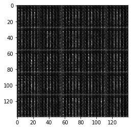

```
E 1/2 D loss: 0.0003 G loss: 11.4213
E 1/2 D loss: 0.0255 G loss: 10.6030
E 1/2 D loss: 7.8117 G loss: 0.0018
E 1/2 D loss: 0.0796 G loss: 7.3436
E 1/2 D loss: 0.0110 G loss: 5.2289
E 1/2 D loss: 3.1866 G loss: 17.4082
E 1/2 D loss: 0.8028 G loss: 6.0465
E 1/2 D loss: 0.8812 G loss: 1.1382
E 1/2 D loss: 0.7587 G loss: 3.0212
E 1/2 D loss: 0.8805 G loss: 2.0332
```

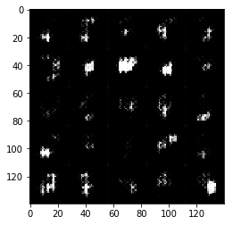

```
E 1/2 D loss: 1.7360 G loss: 0.2744
E 1/2 D loss: 0.8272 G loss: 1.0385
E 1/2 D loss: 0.8007 G loss: 1.0690
E 1/2 D loss: 0.9001 G loss: 0.8494
E 1/2 D loss: 1.1402 G loss: 0.6805
E 1/2 D loss: 1.3248 G loss: 0.8828
E 1/2 D loss: 1.0831 G loss: 0.8005
E 1/2 D loss: 1.1209 G loss: 1.2417
E 1/2 D loss: 1.0613 G loss: 1.0902
E 1/2 D loss: 1.0119 G loss: 0.8900
```

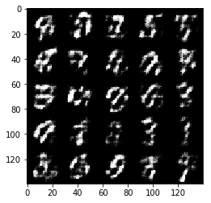

```
E 1/2 D loss: 0.9620 G loss: 1.3692
E 1/2 D loss: 0.8543 G loss: 1.1072
E 1/2 D loss: 1.0456 G loss: 0.7477
E 1/2 D loss: 0.9069 G loss: 1.1404
E 1/2 D loss: 1.1188 G loss: 1.4693
E 1/2 D loss: 0.9989 G loss: 1.1095
E 1/2 D loss: 0.9048 G loss: 0.8155
E 1/2 D loss: 1.0302 G loss: 1.6377
E 1/2 D loss: 0.8638 G loss: 1.7176
E 1/2 D loss: 0.9822 G loss: 0.6544
```

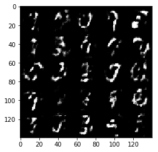

```
E 1/2 D loss: 1.1822 G loss: 2.1441
E 1/2 D loss: 0.8104 G loss: 1.0672
E 1/2 D loss: 0.8176 G loss: 1.4374
E 1/2 D loss: 0.9452 G loss: 2.1740
E 1/2 D loss: 0.9343 G loss: 0.7627
E 1/2 D loss: 1.0362 G loss: 0.6378
E 1/2 D loss: 0.9744 G loss: 0.6508
E 1/2 D loss: 1.2027 G loss: 1.8459
E 1/2 D loss: 1.0332 G loss: 1.0579
E 1/2 D loss: 0.8516 G loss: 1.3451
```

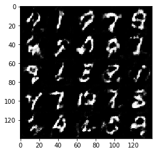

```
E 1/2 D loss: 1.0523 G loss: 0.7614
E 1/2 D loss: 1.0061 G loss: 0.8439
E 1/2 D loss: 1.0480 G loss: 0.6888
E 1/2 D loss: 0.8874 G loss: 1.2213
E 1/2 D loss: 1.0494 G loss: 0.7350
E 1/2 D loss: 1.0437 G loss: 0.6970
E 1/2 D loss: 1.2214 G loss: 0.5452
E 1/2 D loss: 1.2938 G loss: 0.4620
E 1/2 D loss: 1.1672 G loss: 1.6157
E 1/2 D loss: 1.2262 G loss: 1.4669
```

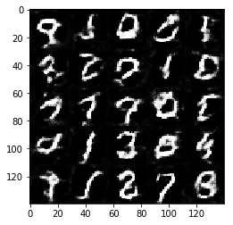

```
E 1/2 D loss: 0.9246 G loss: 0.8994
E 1/2 D loss: 1.1242 G loss: 0.5974
E 1/2 D loss: 1.0888 G loss: 1.3638
E 1/2 D loss: 1.2261 G loss: 0.5046
E 1/2 D loss: 0.9946 G loss: 0.7245
E 1/2 D loss: 1.1359 G loss: 1.3420
E 1/2 D loss: 1.0521 G loss: 0.7085
E 1/2 D loss: 1.4423 G loss: 0.3645
E 1/2 D loss: 0.9610 G loss: 0.8145
E 1/2 D loss: 1.0275 G loss: 0.8916
```

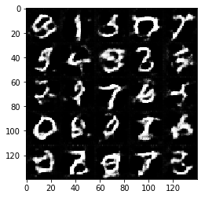

```
E 1/2 D loss: 1.0265 G loss: 1.2771
E 1/2 D loss: 0.9545 G loss: 0.8838
E 1/2 D loss: 0.9738 G loss: 0.8625
E 1/2 D loss: 0.8732 G loss: 1.1814
E 1/2 D loss: 1.0679 G loss: 1.9933
E 1/2 D loss: 0.9808 G loss: 0.9388
E 1/2 D loss: 0.9781 G loss: 0.7874
E 1/2 D loss: 1.0091 G loss: 0.7149
E 1/2 D loss: 1.1622 G loss: 0.5293
E 1/2 D loss: 0.9756 G loss: 1.3579
```

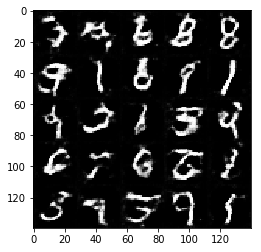

```
E 1/2 D loss: 0.8875 G loss: 1.9530
E 1/2 D loss: 0.9695 G loss: 1.6237
E 1/2 D loss: 1.0072 G loss: 1.6165
E 1/2 D loss: 1.0231 G loss: 0.9565
E 1/2 D loss: 1.0189 G loss: 1.2003
E 1/2 D loss: 1.1031 G loss: 0.6235
E 1/2 D loss: 1.0179 G loss: 1.4748
E 1/2 D loss: 1.0539 G loss: 0.7193
E 1/2 D loss: 1.0212 G loss: 0.8066
E 1/2 D loss: 1.1309 G loss: 0.6428
```

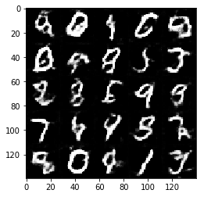

```
E 1/2 D loss: 1.2110 G loss: 0.5325
E 1/2 D loss: 0.9628 G loss: 1.3763
E 1/2 D loss: 1.1906 G loss: 1.6680
E 2/2 D loss: 1.0702 G loss: 0.6660
E 2/2 D loss: 0.9825 G loss: 1.0980
E 2/2 D loss: 0.8644 G loss: 1.0085
E 2/2 D loss: 0.9181 G loss: 0.8583
E 2/2 D loss: 0.9793 G loss: 1.0234
E 2/2 D loss: 0.8924 G loss: 1.1221
E 2/2 D loss: 1.2039 G loss: 0.5061
```

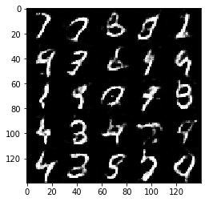

```
E 2/2 D loss: 0.8244 G loss: 1.5205
E 2/2 D loss: 0.8441 G loss: 1.2204
E 2/2 D loss: 0.8332 G loss: 0.9818
E 2/2 D loss: 0.9246 G loss: 0.9296
E 2/2 D loss: 1.1786 G loss: 0.4958
E 2/2 D loss: 0.9940 G loss: 1.4364
E 2/2 D loss: 1.2416 G loss: 0.4333
E 2/2 D loss: 1.3609 G loss: 2.8605
E 2/2 D loss: 0.7810 G loss: 0.9858
E 2/2 D loss: 0.8084 G loss: 0.9961
```

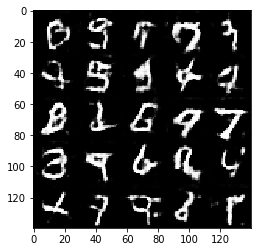

```
E 2/2 D loss: 1.5927 G loss: 0.3024
E 2/2 D loss: 0.8712 G loss: 0.8256
E 2/2 D loss: 0.6995 G loss: 1.3283
E 2/2 D loss: 0.8862 G loss: 1.8106
E 2/2 D loss: 1.0631 G loss: 0.6563
E 2/2 D loss: 0.8434 G loss: 0.8915
E 2/2 D loss: 0.9162 G loss: 0.7741
E 2/2 D loss: 0.8668 G loss: 0.7675
E 2/2 D loss: 0.9824 G loss: 0.7625
E 2/2 D loss: 1.0399 G loss: 0.6068
```

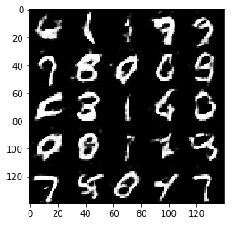

```
E 2/2 D loss: 2.6674 G loss: 3.6455
E 2/2 D loss: 0.9265 G loss: 0.7449
E 2/2 D loss: 0.7346 G loss: 1.1751
E 2/2 D loss: 0.8523 G loss: 0.7928
E 2/2 D loss: 1.0173 G loss: 0.7397
E 2/2 D loss: 1.0284 G loss: 1.9057
E 2/2 D loss: 1.2102 G loss: 0.4889
E 2/2 D loss: 0.7175 G loss: 1.1618
E 2/2 D loss: 0.7399 G loss: 1.1865
E 2/2 D loss: 0.7972 G loss: 0.9844
```

[6 more figures not shown]

```
E 2/2 D loss: 1.7036 G loss: 0.2726
E 2/2 D loss: 0.8324 G loss: 1.0962
E 2/2 D loss: 0.6818 G loss: 1.6125
E 2/2 D loss: 0.8846 G loss: 0.7855
E 2/2 D loss: 1.0876 G loss: 0.6003
E 2/2 D loss: 1.0640 G loss: 1.1497
E 2/2 D loss: 0.7319 G loss: 1.4383
```

```python
batch_size = 64
z_dim = 100
learning_rate = 0.0002
beta1 = 0.5


"""
DON'T MODIFY ANYTHING IN THIS CELL THAT IS BELOW THIS LINE
"""
epochs = 2

mnist_dataset = helper.Dataset('mnist', glob(os.path.join(data_dir, 'mnist/*.jpg')))
with tf.Graph().as_default():
    train(epochs, batch_size, z_dim, learning_rate, beta1, mnist_dataset.get_batches,
          mnist_dataset.shape, mnist_dataset.image_mode)
```

### CelebA

Run your GANs on CelebA. It will take around 20 minutes on the average GPU to run one epoch. You can run the whole epoch or stop when it starts to generate realistic faces.

```
E 1/1 D loss: 0.4705 G loss: 1.5462
E 1/1 D loss: 0.4133 G loss: 1.5374
E 1/1 D loss: 0.1610 G loss: 2.7944
E 1/1 D loss: 0.7733 G loss: 0.8750
E 1/1 D loss: 0.4357 G loss: 1.4436
E 1/1 D loss: 0.8794 G loss: 0.8064
E 1/1 D loss: 0.9346 G loss: 0.9455
E 1/1 D loss: 1.3174 G loss: 0.4735
E 1/1 D loss: 1.1553 G loss: 0.5678
E 1/1 D loss: 0.2484 G loss: 2.5916
```

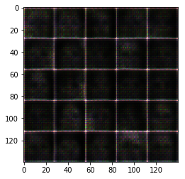

```
E 1/1 D loss: 0.5114 G loss: 2.7593
E 1/1 D loss: 1.5737 G loss: 0.3989
E 1/1 D loss: 1.1435 G loss: 0.8470
E 1/1 D loss: 1.7381 G loss: 0.2721
E 1/1 D loss: 0.4100 G loss: 3.0789
E 1/1 D loss: 0.4234 G loss: 1.7198
E 1/1 D loss: 0.4201 G loss: 2.7377
E 1/1 D loss: 1.0528 G loss: 0.6362
E 1/1 D loss: 0.5850 G loss: 1.4059
E 1/1 D loss: 1.1600 G loss: 0.7576
```

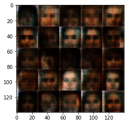

```
E 1/1 D loss: 2.4821 G loss: 0.1238
E 1/1 D loss: 0.8652 G loss: 1.4844
E 1/1 D loss: 0.3026 G loss: 2.6591
E 1/1 D loss: 0.4031 G loss: 1.9909
E 1/1 D loss: 0.5692 G loss: 2.1530
E 1/1 D loss: 1.2401 G loss: 0.6344
E 1/1 D loss: 0.5116 G loss: 2.6150
E 1/1 D loss: 0.9130 G loss: 3.3560
E 1/1 D loss: 0.4087 G loss: 1.9907
E 1/1 D loss: 1.2479 G loss: 5.9996
```

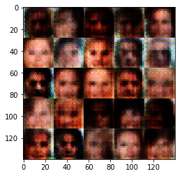

```
E 1/1 D loss: 1.3825 G loss: 0.3759
E 1/1 D loss: 0.5882 G loss: 1.2079
E 1/1 D loss: 0.7061 G loss: 1.0234
E 1/1 D loss: 0.9461 G loss: 0.7942
E 1/1 D loss: 1.2612 G loss: 5.0992
E 1/1 D loss: 0.9868 G loss: 4.2372
E 1/1 D loss: 0.3694 G loss: 5.6976
E 1/1 D loss: 0.5528 G loss: 1.2777
E 1/1 D loss: 0.5897 G loss: 1.1635
E 1/1 D loss: 0.8506 G loss: 0.8069
```

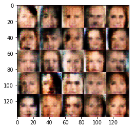

```
E 1/1 D loss: 0.4718 G loss: 1.3668
E 1/1 D loss: 0.7987 G loss: 0.9429
E 1/1 D loss: 0.9399 G loss: 0.6521
E 1/1 D loss: 0.6189 G loss: 1.1658
E 1/1 D loss: 1.8802 G loss: 0.2191
E 1/1 D loss: 0.4501 G loss: 4.6721
E 1/1 D loss: 0.2008 G loss: 3.5921
E 1/1 D loss: 0.3199 G loss: 2.9486
E 1/1 D loss: 0.2210 G loss: 3.0537
E 1/1 D loss: 0.2960 G loss: 2.0481
```

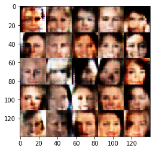

```
E 1/1 D loss: 0.3425 G loss: 1.8975
E 1/1 D loss: 0.1654 G loss: 2.5587
E 1/1 D loss: 0.3299 G loss: 1.6106
E 1/1 D loss: 1.3100 G loss: 0.4207
E 1/1 D loss: 0.3024 G loss: 1.6754
E 1/1 D loss: 0.2394 G loss: 2.1345
E 1/1 D loss: 0.1348 G loss: 4.2246
E 1/1 D loss: 0.3367 G loss: 1.6456
E 1/1 D loss: 0.1551 G loss: 3.8275
E 1/1 D loss: 0.2255 G loss: 4.7415
```

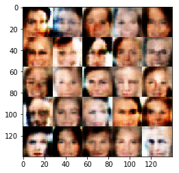

```
E 1/1 D loss: 0.5934 G loss: 5.4503
E 1/1 D loss: 0.5077 G loss: 6.2760
E 1/1 D loss: 0.1068 G loss: 5.1409
E 1/1 D loss: 0.2234 G loss: 4.4589
E 1/1 D loss: 0.2134 G loss: 4.1492
E 1/1 D loss: 0.3655 G loss: 1.6843
E 1/1 D loss: 1.0125 G loss: 0.6583
E 1/1 D loss: 0.1531 G loss: 4.0366
E 1/1 D loss: 0.1828 G loss: 4.2015
E 1/1 D loss: 0.2429 G loss: 3.8795
```

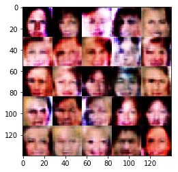

```
E 1/1 D loss: 0.2087 G loss: 3.0409
E 1/1 D loss: 0.2897 G loss: 4.0180
E 1/1 D loss: 0.1571 G loss: 4.4005
E 1/1 D loss: 0.3579 G loss: 4.7142
E 1/1 D loss: 0.4442 G loss: 4.0723
E 1/1 D loss: 0.1825 G loss: 2.2923
E 1/1 D loss: 0.6717 G loss: 1.0312
E 1/1 D loss: 0.3712 G loss: 4.4102
E 1/1 D loss: 0.2737 G loss: 3.0167
E 1/1 D loss: 0.5840 G loss: 1.2572
```

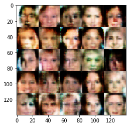

```
E 1/1 D loss: 0.3710 G loss: 3.4976
E 1/1 D loss: 0.7401 G loss: 6.0378
E 1/1 D loss: 0.3324 G loss: 2.9894
E 1/1 D loss: 0.2098 G loss: 2.9273
E 1/1 D loss: 0.3076 G loss: 3.4823
E 1/1 D loss: 0.3811 G loss: 3.2303
E 1/1 D loss: 1.0754 G loss: 4.5603
E 1/1 D loss: 0.4895 G loss: 2.7047
E 1/1 D loss: 0.9199 G loss: 0.7742
E 1/1 D loss: 0.2837 G loss: 2.0454
```

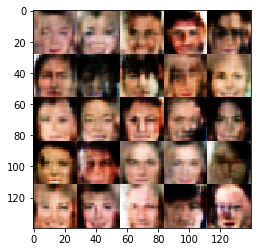

```
E 1/1 D loss: 0.4086 G loss: 1.6102
E 1/1 D loss: 0.7436 G loss: 0.8578
E 1/1 D loss: 0.5676 G loss: 3.4760
E 1/1 D loss: 0.5847 G loss: 1.1502
E 1/1 D loss: 0.3622 G loss: 6.3311
E 1/1 D loss: 0.2855 G loss: 3.0794
E 1/1 D loss: 0.3249 G loss: 3.6619
E 1/1 D loss: 0.3180 G loss: 2.5275
E 1/1 D loss: 0.2899 G loss: 1.8256
E 1/1 D loss: 1.3948 G loss: 0.3817
```

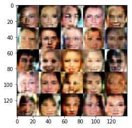

```
E 1/1 D loss: 0.4851 G loss: 3.8383
E 1/1 D loss: 0.1840 G loss: 3.6601
E 1/1 D loss: 0.2856 G loss: 2.2351
E 1/1 D loss: 0.7243 G loss: 6.4873
E 1/1 D loss: 0.5122 G loss: 1.4255
E 1/1 D loss: 0.6744 G loss: 1.0901
E 1/1 D loss: 0.3269 G loss: 1.7874
E 1/1 D loss: 0.1117 G loss: 5.3344
E 1/1 D loss: 0.3068 G loss: 2.2399
E 1/1 D loss: 0.8463 G loss: 5.3277
```

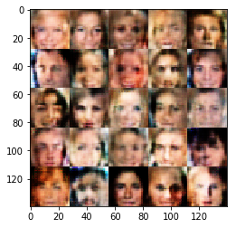

```
E 1/1 D loss: 0.1561 G loss: 3.1208
E 1/1 D loss: 0.2738 G loss: 5.7650
E 1/1 D loss: 0.1708 G loss: 2.7709
E 1/1 D loss: 1.5694 G loss: 9.1657
E 1/1 D loss: 0.8256 G loss: 4.8756
E 1/1 D loss: 0.1792 G loss: 4.1653
E 1/1 D loss: 0.3602 G loss: 2.2119
E 1/1 D loss: 0.1956 G loss: 3.0378
E 1/1 D loss: 0.1083 G loss: 5.1824
E 1/1 D loss: 0.3597 G loss: 1.7131
```

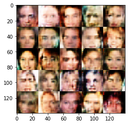

```
E 1/1 D loss: 0.1882 G loss: 5.1472
E 1/1 D loss: 0.5372 G loss: 1.7268
E 1/1 D loss: 0.1279 G loss: 3.3994
E 1/1 D loss: 0.7860 G loss: 2.6788
E 1/1 D loss: 0.2879 G loss: 3.7474
E 1/1 D loss: 0.3692 G loss: 1.7318
E 1/1 D loss: 0.4047 G loss: 2.1948
E 1/1 D loss: 0.3847 G loss: 1.8358
E 1/1 D loss: 0.7186 G loss: 2.4398
E 1/1 D loss: 0.1465 G loss: 5.6712
```

[19 more figures not shown]

```
E 1/1 D loss: 0.6548 G loss: 1.1287
E 1/1 D loss: 1.0796 G loss: 0.6598
E 1/1 D loss: 0.6464 G loss: 2.0325
E 1/1 D loss: 0.4011 G loss: 1.5812
E 1/1 D loss: 0.8305 G loss: 0.7564
E 1/1 D loss: 0.2247 G loss: 2.2954
```

```python
# 128 batch_size yields final g_loss of 0.2800 as per my previous submission
# and is the value used in DCGAN paper, (indico Research and Facebook AI)
# https://arxiv.org/pdf/1511.06434.pdf

# Reviewer suggests this parameter is unreasonable and that I use 64 or 32,
# which yields greater g_loss

batch_size = 64
z_dim = 100
learning_rate = 0.0002
beta1 = 0.5


"""
DON'T MODIFY ANYTHING IN THIS CELL THAT IS BELOW THIS LINE
"""
epochs = 1

celeba_dataset = helper.Dataset('celeba', glob(os.path.join(data_dir, 'img_align_celeba/*.jpg')))
with tf.Graph().as_default():
    train(epochs, batch_size, z_dim, learning_rate, beta1, celeba_dataset.get_batches,
          celeba_dataset.shape, celeba_dataset.image_mode)
```

### Submitting This Project

When submitting this project, make sure to run all the cells before saving the notebook. Save the notebook file as "dlnd_face_generation.ipynb" and save it as a HTML file under "File" -> "Download as". Include the "helper.py" and "problem_unittests.py" files in your submission.